# 2.3 Lab: Introduction to R

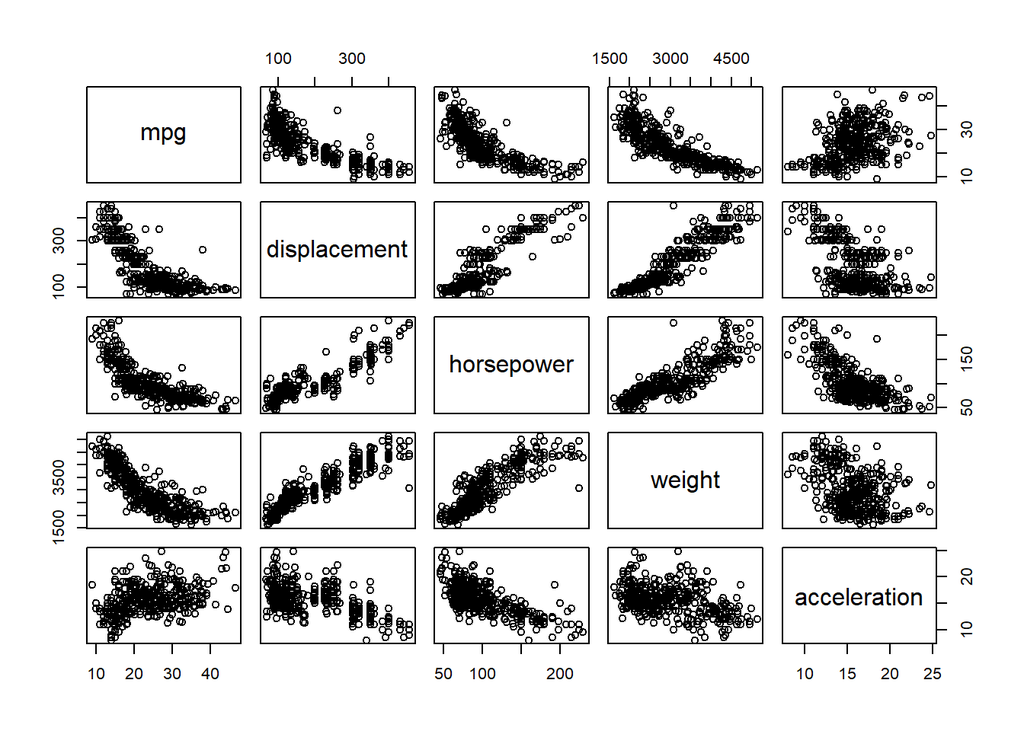

```r
pairs(~ mpg + displacement + horsepower + weight + acceleration, Auto)
```

In conjuction with the **plot()** function, **identify()** provides a useful interactive method for identifying the value for a particular variable for points on a plot. We pass in three arguments to **identify()**: the *x*-axis variable, the*y*-axis variable, and the variable whose values we would like to see printed for each point. Then clicking on a given point in the plot will cause R to print the value of the variable of interset. Right-clicking on the plot will exist the **identify()** function. The numbers printed under the **indetify()** function correspond to the rows for the selected points.

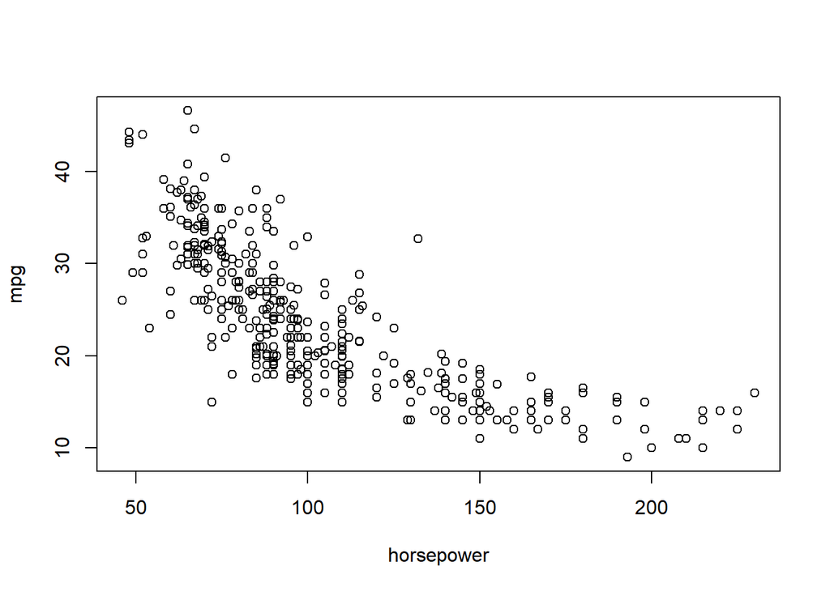

```
integer(0)
```

```r
plot(horsepower, mpg)
identify(horsepower, mpg, name)
```

The **summary()** function produces a numerical summary of each variable in a particular data set.

```r
summary(Auto)
```

```
      mpg          cylinders      displacement     horsepower
 Min.   : 9.00   Min.   :3.000   Min.   : 68.0   Min.   : 46.0
 1st Qu.:17.00   1st Qu.:4.000   1st Qu.:105.0   1st Qu.: 75.0
 Median :22.75   Median :4.000   Median :151.0   Median : 93.5
 Mean   :23.45   Mean   :5.472   Mean   :194.4   Mean   :104.5
 3rd Qu.:29.00   3rd Qu.:8.000   3rd Qu.:275.8   3rd Qu.:126.0
 Max.   :46.60   Max.   :8.000   Max.   :455.0   Max.   :230.0

     weight      acceleration        year           origin
 Min.   :1613   Min.   : 8.00   Min.   :70.00   Min.   :1.000
 1st Qu.:2225   1st Qu.:13.78   1st Qu.:73.00   1st Qu.:1.000
 Median :2804   Median :15.50   Median :76.00   Median :1.000
 Mean   :2978   Mean   :15.54   Mean   :75.98   Mean   :1.577
 3rd Qu.:3615   3rd Qu.:17.02   3rd Qu.:79.00   3rd Qu.:2.000
 Max.   :5140   Max.   :24.80   Max.   :82.00   Max.   :3.000

                 name
 amc matador       :  5
 ford pinto        :  5
 toyota corolla    :  5
 amc gremlin       :  4
 amc hornet        :  4
 chevrolet chevette:  4
 (Other)           :365
```

For qualitative variables such as **name**, R will list the number of observations that fall in each category. We can also produce a summary of just a single variable.

```r
summary(mpg)
```

```
   Min. 1st Qu.  Median    Mean 3rd Qu.    Max.
   9.00   17.00   22.75   23.45   29.00   46.60
```